# ¿Por qué estudiar Series de Tiempo?

Un caso de consultoría con Tiendas 3B en la Ciudad de México

Rodrigo B.

2026-01-01

## Planteamiento

La cadena **Tiendas 3B** contrata un servicio de consultoría para analizar su operación en la **Ciudad de México**. Se tiene disponible un registro **mensual** de sus operaciones en la ciudad de los últimos 6 años, así como la huella de tiendas por alcaldía.

En principio, el objetivo es reportar algunos **business insights** (conclusión relevante que se obtiene al analizar los datos y ayuda a la toma de decisiones) sobre la operación de la empresa y si es posible, realizar un pronóstico de ingresos para los próximos meses.

Se tiene disponible la siguiente información:

**1. Operación mensual en la CDMX** (72 observaciones, enero 2019 – diciembre 2024)

| Variable | Descripción |
| --- | --- |
| `fecha` | Mes al que corresponde el registro |
| `ingresos` | Ingresos totales del mes en la CDMX, en millones de pesos |
| `gasto_publicidad` | Monto invertido en publicidad/marketing ese mes, en millones de pesos |
| `ticket_promedio` | Ticket promedio de compra por cliente, en pesos |
| `num_clientes` | Número de transacciones (clientes) registradas ese mes |
| `temperatura` | Temperatura promedio mensual en la CDMX |

**2. Huella de tiendas por alcaldía** (número de sucursales y desempeño promedio en cada una de las 16 alcaldías de la CDMX en MDP)

| Region | Alcaldia | num_tiendas | ingreso_prom_tienda |
| --- | --- | --- | --- |
| 09002 | Azcapotzalco | 9 | 0.81 |
| 09003 | Coyoacán | 22 | 0.97 |
| 09004 | Cuajimalpa de Morelos | 6 | 1.08 |
| 09005 | Gustavo A. Madero | 15 | 1.00 |
| 09006 | Iztacalco | 19 | 0.99 |

# Explorando los datos

## ¿Dónde está Tiendas 3B en la CDMX?

Es razonable que el primer acercamiento sea la distribución de las sucursales entre las 16 alcaldías. Para visualizar mapas de México usamos el paquete `mxmaps`, que contiene los contornos de los estados y municipios del país. Para este caso, nos interesa la **CDMX**, que está dividida en 16 alcaldías.

[interactive chart not shown]

Figure 1

## Serie de tiempo interactiva

[interactive chart not shown]

Figure 2

Por ahora, **ignoraremos deliberadamente** que estos datos tienen un orden temporal: los tratamos como una tabla transversal más, tal como en el módulo de regresión lineal múltiple.

## Publicidad vs. ingresos

[interactive chart not shown]

Figure 3

## Estacionalidad por mes

[interactive chart not shown]

Figure 4

Noviembre-diciembre y la temporada de calor muestran ingresos sistemáticamente distintos: un primer indicio de **estacionalidad**.

## Mapa de correlaciones interactivo

[interactive chart not shown]

Figure 5

# Aplicando lo aprendido: regresión lineal múltiple

## Planteamiento del modelo

Con las herramientas de inferencia clásica y regresión que ya dominas, el camino natural es modelar los ingresos en función de las demás variables:

$$\text{ingresos}_i = \beta_0 + \beta_1\,\text{gasto\_publicidad}_i +
\beta_2\,\text{ticket\_promedio}_i + \beta_3\,\text{num\_clientes}_i +
\beta_4\,\text{temperatura}_i + \varepsilon_i$$

con el supuesto clásico $\varepsilon_i \sim N(0, \sigma^2)$, **independientes** entre sí.

Cada fila $i$ se trata como una unidad experimental intercambiable, sin importar el orden en que llegó.

## Ajustando el modelo

```
Call:
lm(formula = ingresos ~ gasto_publicidad + ticket_promedio +
    num_clientes + temperatura, data = ventas)

Residuals:
     Min       1Q   Median       3Q      Max
-13.5248  -3.5341   0.2672   3.4083  10.8218

Coefficients:
                   Estimate Std. Error t value Pr(>|t|)
(Intercept)      -1.809e+02  1.714e+01 -10.557 6.82e-16 ***
gasto_publicidad -5.626e-01  3.664e-01  -1.536 0.129312
ticket_promedio   9.307e-01  1.637e-01   5.685 3.10e-07 ***
num_clientes      4.466e-04  1.162e-04   3.845 0.000271 ***
temperatura       1.400e+00  1.306e-01  10.720 3.55e-16 ***
---
Signif. codes:  0 '***' 0.001 '**' 0.01 '*' 0.05 '.' 0.1 ' ' 1

Residual standard error: 5.174 on 67 degrees of freedom
Multiple R-squared:  0.8865,    Adjusted R-squared:  0.8797
F-statistic: 130.8 on 4 and 67 DF,  p-value: < 2.2e-16
```

## Sacándole provecho (I): inferencia sobre coeficientes

| term | estimate | std.error | statistic | p.value | conf.low | conf.high |
| --- | --- | --- | --- | --- | --- | --- |
| (Intercept) | -180.9438 | 17.1400 | -10.5568 | 0.0000 | -215.1553 | -146.7323 |
| gasto_publicidad | -0.5626 | 0.3664 | -1.5357 | 0.1293 | -1.2939 | 0.1686 |
| ticket_promedio | 0.9307 | 0.1637 | 5.6848 | 0.0000 | 0.6039 | 1.2574 |
| num_clientes | 0.0004 | 0.0001 | 3.8446 | 0.0003 | 0.0002 | 0.0007 |
| temperatura | 1.3995 | 0.1306 | 10.7202 | 0.0000 | 1.1390 | 1.6601 |

## Sacándole provecho (II): bondad de ajuste

| r.squared | adj.r.squared | sigma | statistic | p.value |
| --- | --- | --- | --- | --- |
| 0.887 | 0.88 | 5.174 | 130.849 | 0 |

Un $R^2$ ajustado alto y un modelo global significativo. Con lo visto en inferencia clásica, **todo indica que el modelo es bueno**.

## Sacándole provecho (III): predicción puntual

Supongamos que el próximo mes Tiendas 3B planea invertir 7 millones en publicidad en la CDMX, con un ticket promedio de 195 pesos, 130,000 clientes esperados y 20°C de temperatura promedio:

| fit | lwr | upr |
| --- | --- | --- |
| 82.64 | 67.68 | 97.6 |

Con esto, ya podríamos entregarle a Tiendas 3B una estimación puntual **y** un intervalo de predicción. Pareciera que el encargo está resuelto.

## ¿Validamos los supuestos?

Como buenos consultores, antes de entregar el informe revisamos los supuestos clásicos del modelo lineal:

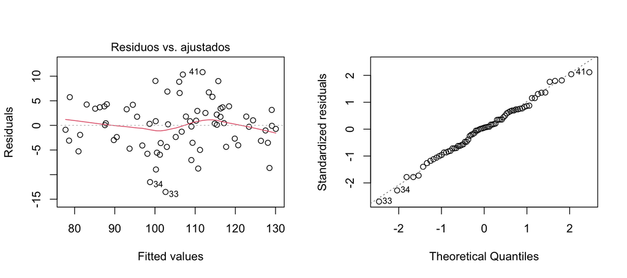

Figure 6

A simple vista, no hay señales dramáticas de no-linealidad ni de falta de normalidad. **Todo parece estar en orden.**

## Un supuesto que aún no hemos revisado…

El modelo lineal asume que los errores $\varepsilon_i$ son **independientes** entre sí. Nunca revisamos eso, porque en un conjunto de datos transversal típico no hay un orden natural para hacerlo.

Pero aquí **sí existe** un orden natural: el tiempo. ¿Qué pasa si graficamos los residuos contra la fecha?

[interactive chart not shown]

Figure 7

## Confirmando la sospecha

Los residuos no se ven como ruido aleatorio: hay rachas, ciclos y un patrón que se repite. Lo confirmamos formalmente:

```
    Durbin-Watson test

data:  modelo
DW = 1.1214, p-value = 1.03e-05
alternative hypothesis: true autocorrelation is greater than 0
```

```
    Box-Ljung test

data:  ventas$residuos
X-squared = 54.765, df = 12, p-value = 1.994e-07
```

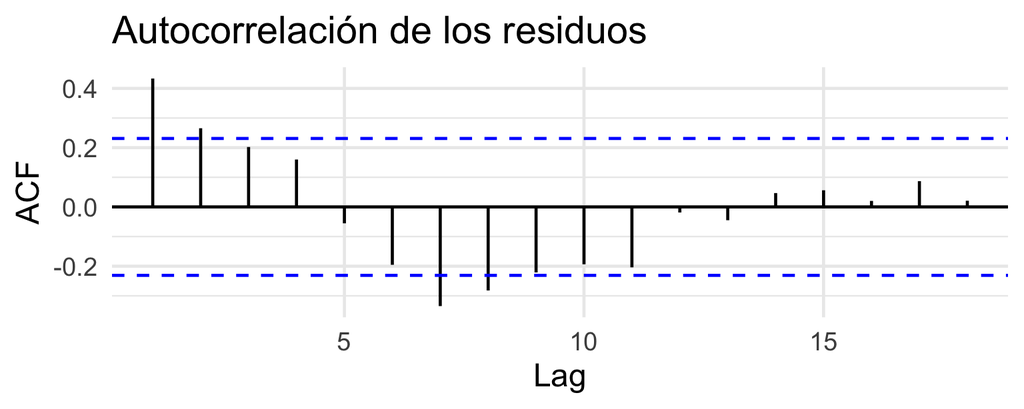

Figure 8

Tanto la prueba de Durbin-Watson como la de Ljung-Box **rechazan** la independencia de los errores. Además, varios rezagos del ACF salen de la banda de confianza.

## ¿Qué implica esto?

- Los **coeficientes** siguen siendo insesgados… pero los **errores estándar** que reporta `lm()` están mal calculados (típicamente subestimados).
- Eso invalida los **intervalos de confianza** y los **valores p** que usamos para “sacarle provecho” al modelo en los pasos anteriores.
- El modelo ignora una fuente de información valiosísima: **el propio pasado de los ingresos** ayuda a explicar el presente, y no lo estamos usando.
- El intervalo de predicción que entregamos asume errores independientes, por lo que probablemente **subestima la incertidumbre real** del pronóstico.
- No hay forma natural de proyectar varios meses hacia adelante: para predecir necesitamos *conocer* las covariables futuras, lo cual rara vez ocurre en la práctica.

## Las limitaciones de fondo

La regresión lineal múltiple —tal como la estudiamos— fue diseñada para datos donde las observaciones son **intercambiables**. Cuando el índice es el tiempo, aparecen preguntas que el modelo no está pensado para responder:

| Pregunta de negocio | ¿La resuelve la regresión clásica? |
| --- | --- |
| ¿Qué variables explican los ingresos? | Sí |
| ¿Los errores estándar/intervalos son confiables? | **No**, si hay autocorrelación |
| ¿Existe una tendencia de largo plazo? | No la modela explícitamente |
| ¿Hay un patrón estacional (meses altos/bajos)? | No la modela explícitamente |
| ¿Cuánto dependen los ingresos de sí mismos en el pasado? | No lo captura |
| ¿Puedo pronosticar *h* meses adelante con incertidumbre creciente y realista? | No, de forma nativa |

# Reconociendo el tiempo

## ¿Qué cambia si modelamos la dependencia temporal?

En vez de tratar cada fila como intercambiable, construimos un objeto que **preserva el orden y la periodicidad** de las observaciones:

```
        Jan    Feb    Mar    Apr    May    Jun    Jul    Aug    Sep    Oct    Nov    Dec
2019  88.53  87.25  92.32  88.96  92.35  91.28  84.55  79.45  76.86  75.53  75.71  88.12
2020  91.28  98.98 101.99  98.59  94.95  98.68  88.20  87.60  86.78  89.96  96.24  97.31
2021 102.81 109.15 112.72 114.89 109.50 105.37  97.84  92.77  89.11  87.26  95.27 102.01
2022 106.22 113.35 117.63 122.31 122.66 115.08 113.48 109.96 101.04 103.47 109.58 105.81
2023 115.52 119.77 123.11 124.56 124.76 118.04 120.10 117.27 108.84 111.20 115.24 120.11
2024 125.44 119.84 129.36 132.20 129.01 126.47 124.51 120.48 117.17 117.57 116.68 123.23
```

Ahora el modelo puede “ver” que enero de 2020 sigue a diciembre de 2019, y que ambos son parte de un ciclo anual de 12 meses.

## Descomponiendo la serie

Una primera ganancia inmediata: **descomponer** la serie en tendencia, estacionalidad y componente irregular — algo que la regresión clásica nunca nos mostró de forma explícita.

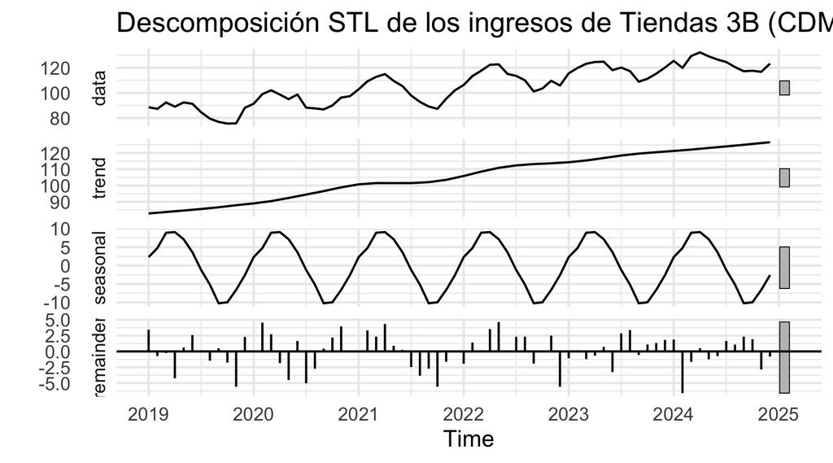

Figure 9

## ACF y PACF: herramientas propias de las series de tiempo

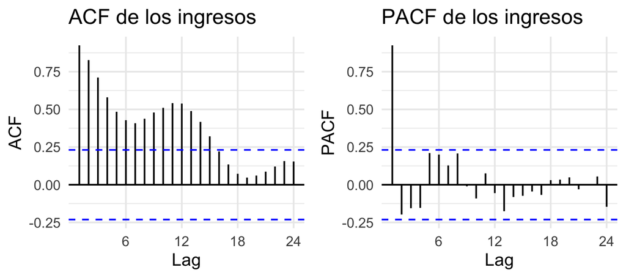

Figure 10

El ACF/PACF nos permite **ver directamente** cuánto se parece cada mes a los meses anteriores: información que la regresión lineal simplemente no tiene manera de mostrar.

## Modelando la dependencia: regresión + series de tiempo

No se trata de “tirar a la basura” lo aprendido en regresión: los modelos de series de tiempo permiten **combinar** covariables externas con la estructura temporal de los errores (modelos tipo *ARIMAX*):

```
Series: ingresos_ts
Regression with ARIMA(2,0,1)(0,0,1)[12] errors

Coefficients:
         ar1      ar2      ma1   sma1  intercept  gasto_publicidad  ticket_promedio
      1.6696  -0.8319  -0.5324  0.612   -151.234            2.3052           1.1071
s.e.  0.0851   0.0797   0.1447  0.168     35.042            0.2995           0.1638
      num_clientes  temperatura
             1e-04      -0.0238
s.e.         0e+00       0.1702

sigma^2 = 8.87:  log likelihood = -180.05
AIC=380.1   AICc=383.71   BIC=402.87

Training set error measures:
                    ME     RMSE      MAE        MPE     MAPE      MASE        ACF1
Training set 0.1002727 2.785844 2.391735 -0.0369486 2.325117 0.3063774 -0.06893889
```

## ¿Ahora sí son independientes los errores?

```
    Ljung-Box test

data:  Residuals from Regression with ARIMA(2,0,1)(0,0,1)[12] errors
Q* = 9.1437, df = 10, p-value = 0.5185

Model df: 4.   Total lags used: 14
```

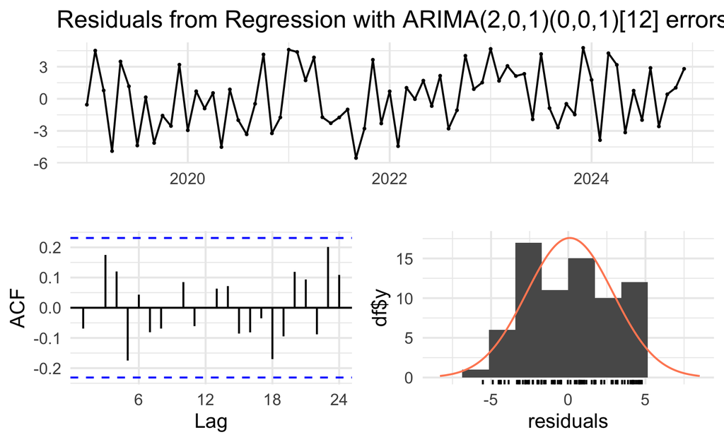

Figure 11

## Pronosticando con incertidumbre realista

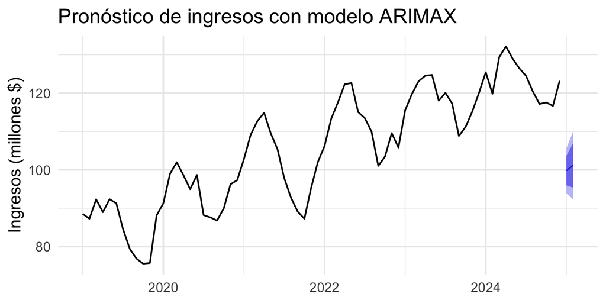

Figure 12

Ahora el intervalo de pronóstico **crece con el horizonte**, reflejando que mientras más lejos proyectamos, menos sabemos — algo que la regresión clásica, con errores independientes, no puede representar.

## Regresión clásica vs. modelos de series de tiempo

| Aspecto | Regresión lineal múltiple | Modelos de series de tiempo |
| --- | --- | --- |
| Supuesto sobre las observaciones | Intercambiables / independientes | Ordenadas, con posible dependencia |
| Qué hace con la autocorrelación | La ignora (o la viola) | La modela explícitamente |
| Tendencia y estacionalidad | No se modelan de forma nativa | Se descomponen y modelan |
| Pronóstico a *h* pasos | Requiere covariables futuras conocidas | Genera incertidumbre creciente y coherente |
| Validez de errores estándar/IC | Comprometida si hay autocorrelación | Corregida por el propio modelo |
| Relación con lo ya aprendido | — | Extiende la regresión (ARIMAX), no la reemplaza |

## Moraleja para Tiendas 3B

- La regresión lineal múltiple **no estaba mal usada**: siguió correctamente cada paso de inferencia clásica.
- El problema fue **no reconocer la estructura temporal** de los datos antes de confiar en esa inferencia.
- Cuando el índice de tus datos es el tiempo, ignorarlo tiene un costo: conclusiones estadísticas inválidas y pronósticos poco confiables.
- Las series de tiempo no descartan lo aprendido — lo **extienden**, dándote herramientas para tendencia, estacionalidad, dependencia y pronóstico.

## Lo que viene en el curso

- Estacionariedad y transformaciones (diferenciación, logaritmos)
- Autocorrelación: ACF y PACF como herramientas de diagnóstico
- Descomposición clásica y STL
- Suavizamiento exponencial (Holt-Winters)
- Modelos ARIMA / SARIMA y su relación con la regresión
- Incorporación de covariables externas (ARIMAX)
- Evaluación y validación de pronósticos

## ¡Gracias!

**Preguntas y discusión**

*El caso de Tiendas 3B en la CDMX seguirá acompañándonos a lo largo del curso.*